# Coursework Report

*N* removed NAs: 3

*N* removed typo: 1

*N* removed <18: 30

*N* total clean: 116

| Group | *N* | *M*<sub>age</sub> | *M*<sub>rating</sub> |
| --- | --- | --- | --- |
| Control | 59 | 20.53 | 5.28 |
| Experim | 57 | 20.40 | 6.54 |

**Main analysis results**

*t*(114) = -8.87, *p* < .001

[interactive chart not shown]

[figure not shown]

[interactive chart not shown]

# Coursework Report

Analysing Data, Spring 2020

# Methods

## Participants

Figure 1 *Descriptive statistics by Condition*

| Condition | *N* | % | *M*<sub>age</sub> | *SD*<sub>age</sub> |
| --- | --- | --- | --- | --- |
| control | 59 | 50.86 | 20.53 | 1.93 |
| experimental | 57 | 49.14 | 20.40 | 1.90 |

## Design

The initial research question that this study was investigating is that the colour red changes the level of female sexual attraction to men. The independent variable in this study was colour, the experimental condition presenting a red background and the control condition presenting white. The aim of this research was to measure a change in levels of attractiveness.

Percieved attractiveness was assessed through questions about the appearance of the individual. Three questions were asked: “How attractive do you think this person is?”, “How pleasant is this person to look at?” and “If I were to meet the person in this picture face to face, would I think he is attractive.” Ratings of attractiveness were measured on a scale of 1 (not at all attractive) to 9 (extremely attractive). The female participants were shown either a black and white photo of a man on a red background or a white background to base their ratings on.

Overall, we wanted to test whether mean ratings of attractiveness would be higher if an image of a man was presented on a red background rather than white. This was tested using an independent measures *t*-test.

# Results

Therefore, in the condition where an image of a man’s face was shown on a red background, rather than white, ratings of attractiveness were generally higher.

The figure below shows the mean ratings of attraction by condition.

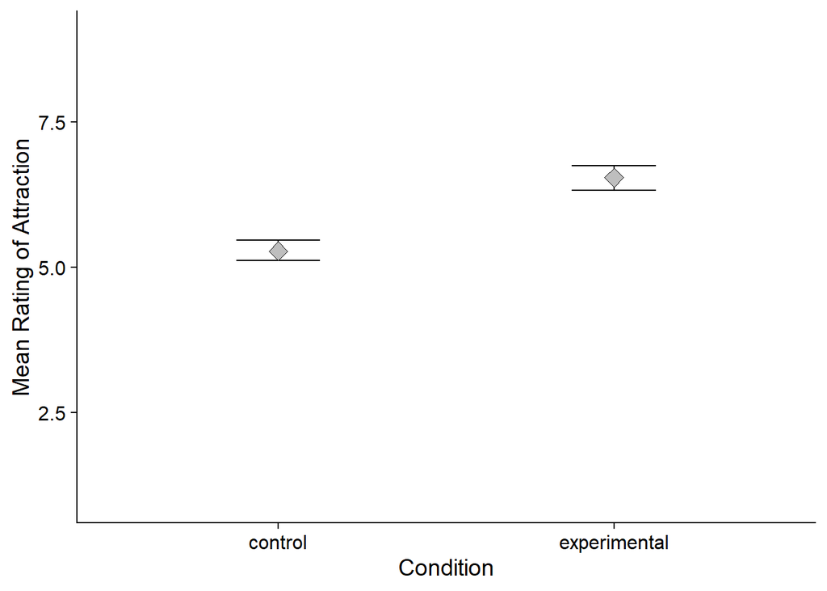

# Discussion

The purpose of this resarch was to test whether presenting a woman with an image of a male face on either a red or white background would affect their level of attraction towards them. Our results show that the colour red did influence the man’s percieved attractiveness as ratings were higher in the experimental condition compared to the control. Therefore, our hypothesis was supported, and as with the original study (Elliot et al., 2010) our results provided some support for the effects of red on the percieved attractiveness of a man. Our results provide further evidence for the red effect, however, it would be imperative that other examples in this area of research were analysed and new questions investigated in order to report a correlation.

Other studies (Prokop, Pazda & Elliot, 2015) have also provided support for these findings, however, they found that this effect was only prevalent in women of high conception probability, and was not found for women of low concpetion probability. This suggests that other factors may also influence the extent to which the colour red has an effect on male attractiveness. Penton-Voak et al. (1999) research also shows a link between female ovulatory cycle and attraction. They found that female preference for male faces differs depending on their stage of mensturation. For example, women preferred a more masculine face at the more fertile point of their ovulatory cycle. This suggests that red may not be the strongest influence on female attraction and other influences should be taken into consideration when investigating this.

Waitt et al. (2003) investigated rhesus monkeys and found that female monkeys exhibited a preference for the computer manipulated redder versions of male faces. They argue that this is due to the indiciation of male quality as their faces tend to redden during mating season. Additionally, a similar result was found in red winged blackbirds (Yasukawa, Butler & Enstrom, 2009). Results show that females associated far more with birds that were redder than normal, and they were more likely to perform precopulatory displays to redder males. For the effect of red on females that we investgated in the present study, this research provides a basis for our hypothesis to be made. Furthermore it provides support for this idea and show that it is not only social and due to status, but also has a biological basis and occurs in other species.

A limitation of our study is that it still provides no evidence that the colour red signals high status, as the results only show that there was a higher attraction to males associated with red. Therefore, we cannot make the assumption that this preference was linked to status. However, previous research has shown that there is a link between red and high status (Little & Hill, 2007) but there is no evidence in our results to support this. Moreover, our research has not applied these effects to real-life situtions, therefore this study may be hard to generalise as it is unlikely that attrcation levels will be the same when looking at a picture in comparison to real life. A further limitation of our study is that it failed to explore female attraction to males in terms of their clothing or surroundings rather than solely a photo.

These gaps in our understanding of this area provide an excellent basis for future research and the developing of this topic. This area is definitely worth investigating further as our research has not fully answered remaining questions. The first suggestion for future studies would be to look at female attraction to males associated with the colour red, but also in terms of their stage in ovulatory cycle. This is because there is a vast amount of research suggesting that this has a strong influence on male preference from a female perspective, yet there is no research looking at the effect that these two factors may have on each other. Another important area that should be focused on in the future is replicating these effects in a situation closer to real life. This would have positive implications as it would broaden our understanding and allow us to generalise our results further.

To conclude, the main findings of our study are that the colour red increases female attraction to males. However, the weak areas of our study, such as lack of correlation to status and generalisability, provide a basis for future research questions and show that this area still has many avenues to be discovered.

# References

Elliot, A. J., Niesta Kayser, D., Greitemeyer, T., Lichtenfeld, S., Gramzow, R. H., Maier, M. A., & Liu, H. (2010). Red, rank, and romance in women viewing men. *Journal of Experimental Psychology: General*, 139(3), 399.

Little, A. C., & Hill, R. A. (2007). Attribution to red suggests special role in dominance signalling. *Journal of evolutionary psychology*, 5(1), 161-168.

Penton-Voak, I. S., Perrett, D. I., Castles, D. L., Kobayashi, T., Burt, D. M., Murray, L. K., & Minamisawa, R. (1999). Menstrual cycle alters face preference. *Nature*, 399(6738), 741-742.

Prokop, P., Pazda, A. D., & Elliot, A. J. (2015). Influence of conception risk and sociosexuality on female attraction to male red. *Personality and Individual Differences*, 87, 166-170.

Waitt, C., Little, A. C., Wolfensohn, S., Honess, P., Brown, A. P., Buchanan-Smith, H. M., & Perrett, D. I. (2003). Evidence from rhesus macaques suggests that male coloration plays a role in female primate mate choice. *Proceedings of the Royal Society of London. Series B: Biological Sciences*, 270(suppl_2), S144-S146.

Yasukawa, K., Butler, L. K., & Enstrom, D. A. (2009). Intersexual and intrasexual consequences of epaulet colour in male red-winged blackbirds: an experimental approach. *Animal Behaviour*, 77(2), 531-540.